# analysis of Jeong & Cherone datasets

tgermade

2020-08-03

```r
suppressPackageStartupMessages({
  library(ggplot2)
  library(SummarizedExperiment)
  library(plgINS)
  library(viridis)
  library(RColorBrewer)
  library(dplyr)
  library(cowplot)
  library(ggrepel)
})
```

# Functions

```r
targetFCs <- function(se, TS, seed, pertname){
  # find target genes
  TS$sites <- round(TS$sites)
  TS.target <- TS[TS$family==seed,]
  # generate df
  m <- data.frame(log2FC=rowMeans(assays(se[,se$miRNA==pertname])$log2FC),
                  symbol=sapply(rownames(se), function(x) paste(unlist(strsplit(x, split="\\."))[-1], collapse=".") )
                  )
  m$cat <- factor( sapply(m$symbol, function(x) if(x %in% TS.target$feature) "target" else "nontarget") )
  return(m)
}
```

# Load

```r
se.jeong <- readRDS("../master_19_20/enrichMiR_benchmark/data/jeong.DEA.SE.rds")
TS.human <- readRDS("../master_19_20/enrichMiR_benchmark/data/TargetScan_human.rds")

se.cherone.d0 <- readRDS("../master_19_20/enrichMiR_benchmark/data/cherone.d0.DEA.SE.rds")
se.cherone.d1 <- readRDS("../master_19_20/enrichMiR_benchmark/data/cherone.d1.DEA.SE.rds")
TS.mouse <- readRDS("../master_19_20/enrichMiR_benchmark/data/TargetScan_mouse.rds")

se.amin <- readRDS("../master_19_20/enrichMiR_benchmark/data/amin.DEA.SE.rds")
```

# Jeong dataset

## Prep

```r
seed.jeong <- "GCUACAU"
m <- targetFCs(se.jeong, TS.human, seed.jeong, "DKO")
```

Comment: not all genes contained in TS.target are found inside the se object. This is probably due to the expression cutoffs that were performed when the se object was created.

## Stats

```r
table(m$cat)
```

```
##
## nontarget    target
##     16528       380
```

```r
t.test(m$log2FC[m$cat=="target"], m$log2FC[m$cat!="target"], alternative = "greater")
```

```
##
##  Welch Two Sample t-test
##
## data:  m$log2FC[m$cat == "target"] and m$log2FC[m$cat != "target"]
## t = 0.59666, df = 397.52, p-value = 0.2755
## alternative hypothesis: true difference in means is greater than 0
## 95 percent confidence interval:
##  -0.02067278         Inf
## sample estimates:
##    mean of x    mean of y
## -0.007854696 -0.019579199
```

Note: With this t-test we only check if we see larger values than H0 in the subset. This makes sense since all the datasets here are created by miRNA KO.

## Plots

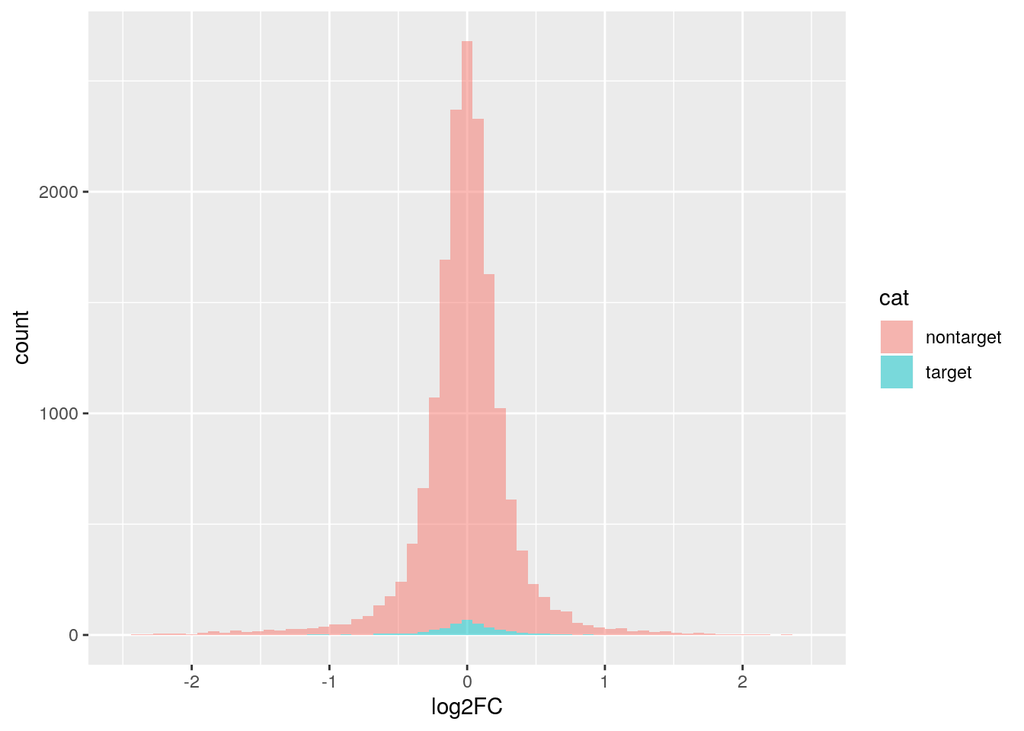

```r
ggplot(m, aes(x=log2FC)) + geom_histogram(aes(fill=cat), alpha=0.5, binwidth=.08) + scale_x_continuous(limits = c(-2.5,2.5))
```

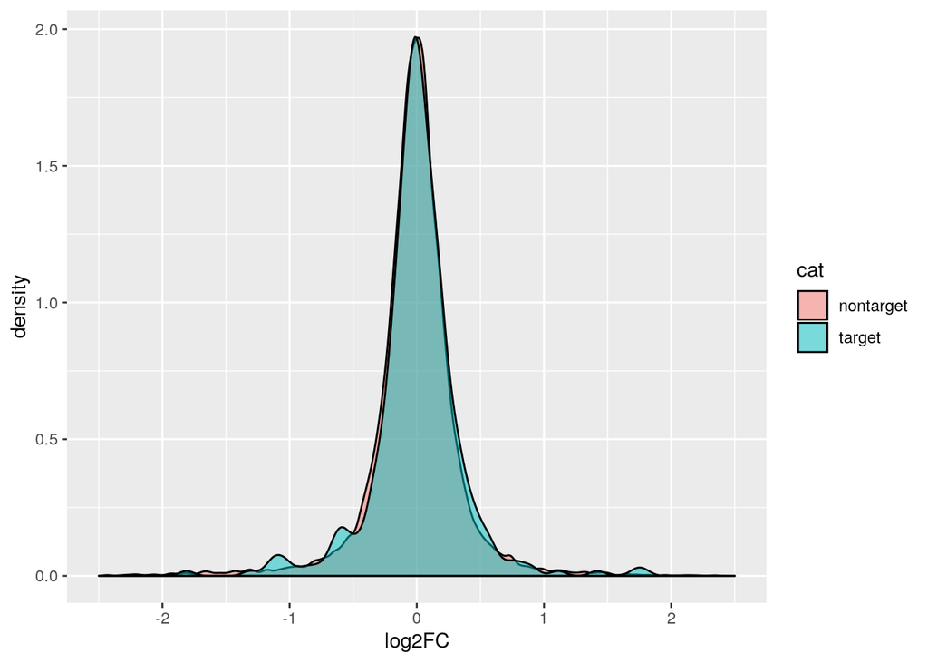

```r
ggplot(m, aes(x=log2FC)) + geom_density(aes(fill=cat), alpha=0.5) + scale_x_continuous(limits = c(-2.5,2.5))
```

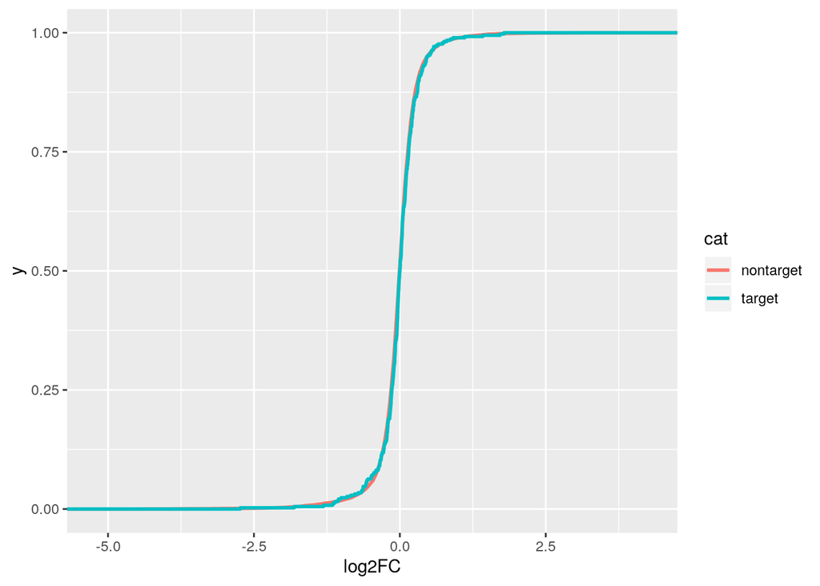

```r
ggplot(m, aes(x=log2FC, colour=cat)) + stat_ecdf(size=1)
```

Summary: It doesn’t seem like the log2FC distribution of targets and non-targets differ.

# Amin dataset (control)

This is introduced as an example of how the distributions look like for a dataset with non-cero TP rates for many of the enrichMiR tests. This just serves as a reference.

## Prep

```r
seed.amin <- "UGUGCUU"
m <- targetFCs(se.amin, TS.mouse, seed.amin, "218DKO")
```

## Stats

```r
table(m$cat)
```

```
##
## nontarget    target
##     13757       852
```

```r
t.test(m$log2FC[m$cat=="target"], m$log2FC[m$cat!="target"], alternative = "greater")
```

```
##
##  Welch Two Sample t-test
##
## data:  m$log2FC[m$cat == "target"] and m$log2FC[m$cat != "target"]
## t = 22.639, df = 969.52, p-value < 2.2e-16
## alternative hypothesis: true difference in means is greater than 0
## 95 percent confidence interval:
##  0.2011095       Inf
## sample estimates:
##  mean of x  mean of y
##  0.2034661 -0.0134160
```

## Plots

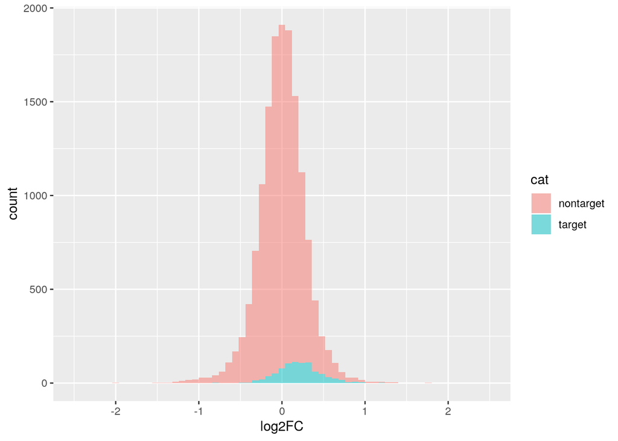

```r
ggplot(m, aes(x=log2FC)) + geom_histogram(aes(fill=cat), alpha=0.5, binwidth=.08) + scale_x_continuous(limits = c(-2.5,2.5))
```

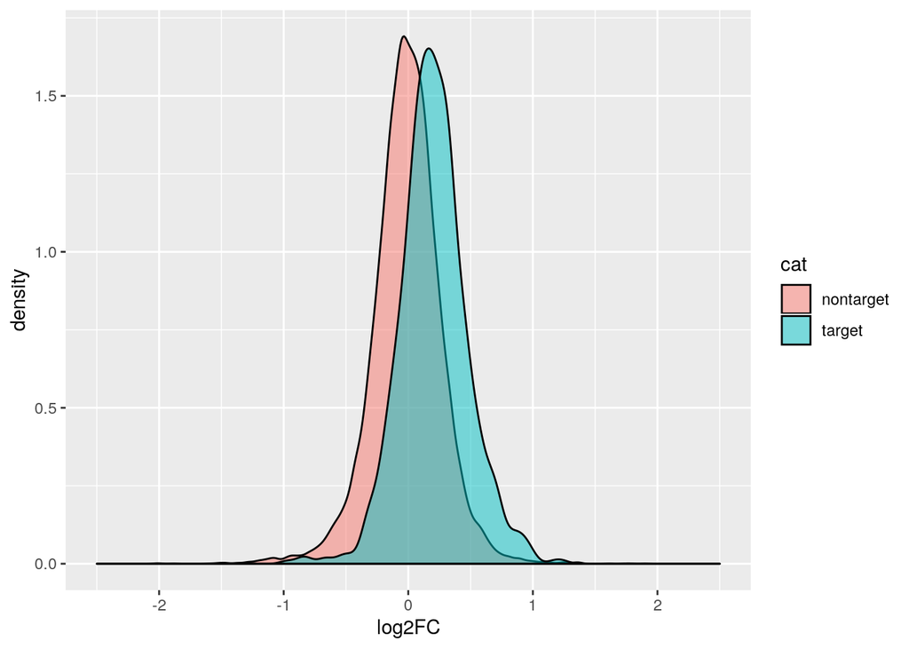

```r
ggplot(m, aes(x=log2FC)) + geom_density(aes(fill=cat), alpha=0.5) + scale_x_continuous(limits = c(-2.5,2.5))
```

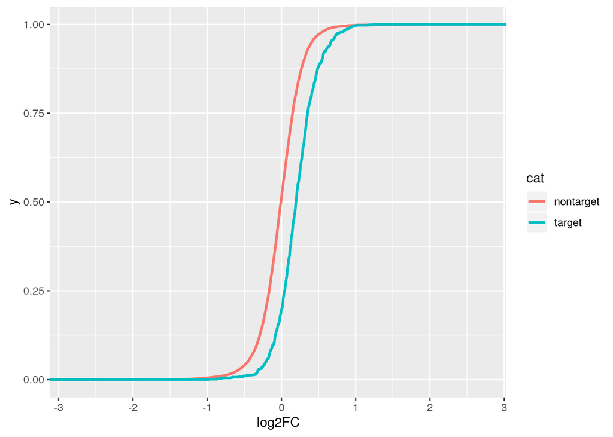

```r
ggplot(m, aes(x=log2FC, colour=cat)) + stat_ecdf(size=1)
```

# Cherone dataset (correction)

In my thesis I used the sequence CUAUUUC (miR-138-2-3p) for the miR-138 perturbation in Cherone. I intended to correct this since I checked enrichMiR test ranks for all the possible seed sequences and only the GCUGGUG (miR-138-5p) gave sensible results. However, I mistakenly ran enrichMiR with unaltered variables. This mistake is now in the thesis. Here I compare the sensible results with those displayed in the thesis.

## Prep

```r
filedir <- "/mnt/schratt/tgermade_test/master_19_20/enrichMiR_benchmark/results/"

# input files: Bartel DEA SE
input <- list(
  bartel.hek=paste0(filedir, "bartel.hek.benchmark.rds"),
  bartel.hek.exon=paste0(filedir, "bartel.hek.exon.benchmark.rds"),
  bartel.hela=paste0(filedir, "bartel.hela.benchmark.rds"),
  bartel.hela.exon=paste0(filedir, "bartel.hela.exon.benchmark.rds"),
  jeong=paste0(filedir, "jeong.benchmark.rds"),
  jeong.exon=paste0(filedir, "jeong.exon.benchmark.rds"),
  rat=paste0(filedir, "ratPolyA.benchmark.rds"),
  rat.exon=paste0(filedir, "ratPolyA.exon.benchmark.rds"),

  bartel.hek.mirexpr=paste0(filedir, "bartel.hek.mirexpr.benchmark.rds"),
  bartel.hek.exon.mirexpr=paste0(filedir, "bartel.hek.exon.mirexpr.benchmark.rds"),
  bartel.hela.mirexpr=paste0(filedir, "bartel.hela.mirexpr.benchmark.rds"),
  bartel.hela.exon.mirexpr=paste0(filedir, "bartel.hela.exon.mirexpr.benchmark.rds"),
  rat.mirexpr=paste0(filedir, "ratPolyA.mirexpr.benchmark.rds"),
  rat.exon.mirexpr=paste0(filedir, "ratPolyA.exon.mirexpr.benchmark.rds"),

  amin=paste0(filedir, "amin.benchmark.rds"),
  amin.exon=paste0(filedir, "amin.exon.benchmark.rds"),
  cherone.d0=paste0(filedir, "cherone.d0.benchmark2.rds"),
  cherone.d0.exon=paste0(filedir, "cherone.d0.exon.benchmark2.rds"),
  cherone.d1=paste0(filedir, "cherone.d1.benchmark2.rds"),
  cherone.d1.exon=paste0(filedir, "cherone.d1.exon.benchmark2.rds"),

  amin.mirexpr=paste0(filedir, "amin.mirexpr.benchmark.rds"),
  amin.exon.mirexpr=paste0(filedir, "amin.exon.mirexpr.benchmark.rds"),
  cherone.d0.mirexpr=paste0(filedir, "cherone.d0.mirexpr.benchmark.rds"),
  cherone.d0.exon.mirexpr=paste0(filedir, "cherone.d0.exon.mirexpr.benchmark.rds"),
  cherone.d1.mirexpr=paste0(filedir, "cherone.d1.mirexpr.benchmark.rds"),
  cherone.d1.exon.mirexpr=paste0(filedir, "cherone.d1.exon.mirexpr.benchmark.rds")
  )

TPs <- c(
  let.7a = "GAGGUAG", lsy.6 = "UUUGUAU", miR.1 = "GGAAUGU", miR.124 = "AAGGCAC",
  miR.137 = "UAUUGCU", miR.139 = "CUACAGU", miR.143 = "GAGAUGA",
  miR.144 = "ACAGUAU", miR.153 = "UGCAUAG", miR.155 = "UAAUGCU",
  miR.182 = "UUGGCAA", miR.199a = "CCAGUGU", miR.204 = "UCCCUUU",
  miR.205 = "CCUUCAU", miR.216b = "AAUCUCU", miR.223 = "GUCAGUU",
  miR.7 = "GGAAGAC", miR.122 = "GGAGUGU", miR.133 = "UGGUCCC",
  miR.138 = "GCUGGUG", miR.145 = "UCCAGUU", miR.184 = "GGACGGA",
  miR.190a = "GAUAUGU", miR.200b = "AAUACUG", miR.216a = "AAUCUCA",
  miR.217 = "ACUGCAU", miR.219a = "GAUUGUC", miR.375 = "UUGUUCG",
  miR.451a = "AACCGUU", "DKOvWT"="GCUACAU", "DKO"="GCUACAU",
  "miR.138vNeg"="GCUGGUG", "miR.499vNeg"="UAAGACU", "miR.499"="UAAGACU",
  "218DKOvWT"="UGUGCUU", "218DKO"="UGUGCUU",
  "138DKOvWT"="GCUGGUG", "138DKO"="GCUGGUG"
  )
```

```r
# import dataframes
df.list <- lapply(input,readRDS)
```

```r
# combine dataframes
df <- do.call("rbind", df.list)
# add information
df$sample <- sapply(strsplit(rownames(df),"\\."), function(x) paste(rev(rev(x)[-1]),collapse="."))
df$dataset <- sapply(strsplit(df$sample,"\\."), function(x) x[1])
df$organism <- sapply(df$dataset, function(x){
  if(x=="bartel" | x=="jeong") "human"
  else if(x=="rat") "rat"
  else if(x=="amin" | x=="cherone" | x=="whipple") "mouse"
})
df$celltype <- sapply(df$sample, function(x){
  if(grepl("hek",x)) "HEK293"
  else if(grepl("hela",x)) "HeLa"
  else if(grepl("jeong",x)) "SNU-638"
  else if(grepl("rat",x)) "hippocampal_neurons/glia"
  else if(grepl("in",x)) "induced_neurons"
  else if(grepl("esc",x)) "ESC"
  else if(grepl("amin",x)) "motoneurons"
  else if(grepl("cherone",x)) "CAD"
})
df$miRNA <- sapply(1:nrow(df), function(i){
  if(df$dataset[i]=="bartel") df$treatment[i]
  else if(df$dataset[i]=="rat" & grepl("miR.138",df$treatment[i])) "miR.138"
  else if(df$dataset[i]=="rat" & grepl("miR.499",df$treatment[i])) "miR.499"
  else if(df$dataset[i]=="jeong") "miR.221/miR.222"
  else if(df$dataset[i]=="amin") "miR.218"
  else if(df$dataset[i]=="cherone") "miR.138"
})
df$seed <- sapply(df$treatment, function(x) TPs[x])
df$design <- factor( sapply(df$dataset, function(x){
  if(x=="bartel" | x=="rat") "transfection"
  else if(x=="jeong" | x=="amin" | x=="cherone" | x=="whipple") "KO"
  }), levels=c("transfection","KO") )
df$exon.specific <- factor( sapply(df$sample, function(x) if(grepl("exon",x)) "exonic" else "unseparated"), levels=c("unseparated","exonic") )
df$mirexpr <- factor( sapply(df$sample, function(x) if(grepl("mirexpr",x)) "mirexpr" else "no_mirexpr"), levels=c("no_mirexpr","mirexpr") )

# we get rid of tests in the wrong direction with respect to intervention (mistake in amin dataset):
df <- df[ (df$design=="transfection" & !grepl("\\.up",df$method)) |
          (df$design!="transfection" & df$dataset!="amin" & !grepl("\\.down",df$method)) |
          (df$dataset=="amin" & !grepl("\\.up",df$method)), ]
df$method <- gsub("\\.down|\\.up","",df$method)
# get rid of NAs in detPPV
df$detPPV[is.na(df$detPPV)] <- 0

# correct some treatment names
for(x in c("bartel","rat","cherone")){
  df$treatment[df$dataset==x & df$miRNA=="miR.138"] <- paste0("miR.138.",x)
}
df$treatment[df$dataset=="jeong"] <- "miR.221/miR.222"
df$treatment[df$treatment=="miR.499vNeg"] <- "miR.499"
df$treatment[df$treatment %in% c("218DKOvWT","218DKO")] <- "miR.218"

# mark bartel dataset
for(x in unique(df$dataset)){
  if(x=="bartel") df$is.bartel[df$dataset==x] <- "bartel"
  else df$is.bartel[df$dataset==x] <- "other"
}

# remove lsy.6 bartel
df <- df[df$treatment!="lsy.6",]

# convert columns to factors
for(x in colnames(df)[-which(colnames(df) %in% c("detPPV","FP.atFDR05","log10QDiff","log10QrelIncrease","TP.atFDR05"))]){
  df[[x]] <- as.factor(df[[x]])
}

# variables
#dea.names <- as.character(unique(df$treatment))
#props.all <- levels(df$prop)
```

```r
df.old <- readRDS("../master_19_20/enrichMiR_benchmark/results/combined.benchmark.rds")
```

```r
# color palette dataset
newCols <- colorRampPalette(grDevices::hcl.colors(length(unique(df$dataset)),palette = hcl.pals()[107]))
cols.data <- newCols(length(unique(df$dataset)))
names(cols.data) <- levels(df$dataset)
# color palette method
set.seed(111)
colourCount = length(levels(df$method))
getPalette = colorRampPalette(brewer.pal(9, "Set1")[-6])
cols.method <- structure(sample(getPalette(colourCount)), names=levels(df$method))
# color palette design
cols.design <- structure(cols.method[c(4,5)], names=levels(df$design))
# color palette mirexpr
cols.mir <- structure(cols.design, names=levels(df$mirexpr))
# color palette exon.specific
cols.ex <- structure(cols.design, names=levels(df$exon.specific))

colors <- list(dataset=cols.data,
               method=cols.method,
               design=cols.design,
               mir=cols.mir,
               ex=cols.ex)
```

```r
DFaggregation <- function(df){
  df.std <- df[df$mirexpr=="no_mirexpr" & df$exon.specific=="unseparated",]
  ## get average number of FP & TP at FDR .05 for each combination of permutation & method & mirexpr
  df.agg <- aggregate(df.std[,c("FP.atFDR05","TP.atFDR05")], by=df.std[,c("prop","method","dataset","sample","design")], FUN=mean)
  df.agg$dataset <- as.character(df.agg$dataset)
  df.agg$dataset[df.agg$sample=="bartel.hela"] <- as.character(df.agg$sample[df.agg$sample=="bartel.hela"])
  df.agg$dataset[df.agg$sample=="bartel.hek"] <- as.character(df.agg$sample[df.agg$sample=="bartel.hek"])
  df.agg$dataset <- factor(df.agg$dataset)
  df.agg <- aggregate(df.agg[,c("FP.atFDR05","TP.atFDR05")], by=df.agg[,c("prop","method","dataset","design")], FUN=mean)
  return(df.agg)
}
```

```r
# "GGCUACU" is miR-138-1-3p. This isn't found in the TS.mouse

# this is the seed we used (wrongly), miR-138-2-3p
seed.cherone <- "CUAUUUC"

d0 <- targetFCs(se.cherone.d0, TS.mouse, seed.cherone, "138DKO")
d1 <- targetFCs(se.cherone.d1, TS.mouse, seed.cherone, "138DKO")

before.corr <- gdata::combine(d0,d1)

# this is miR-138-5p
seed.cherone <- "GCUGGUG"

d0 <- targetFCs(se.cherone.d0, TS.mouse, seed.cherone, "138DKO")
d1 <- targetFCs(se.cherone.d1, TS.mouse, seed.cherone, "138DKO")

after.corr <- gdata::combine(d0,d1)

m <- gdata::combine(before.corr, after.corr)
```

## Stats

```r
table(m$cat, m$source.1)
```

```
##
##             before.corr after.corr
##   nontarget       31160      30129
##   target             15       1046
```

### before correction

```r
mbef <- m[m$source.1=="before.corr",]

# d0
t.test(mbef$log2FC[mbef$source=="d0" & mbef$cat=="target"], mbef$log2FC[mbef$source=="d0" & mbef$cat!="target"], alternative = "greater")
```

```
##
##  Welch Two Sample t-test
##
## data:  mbef$log2FC[mbef$source == "d0" & mbef$cat == "target"] and mbef$log2FC[mbef$source == "d0" & mbef$cat != "target"]
## t = 0.13117, df = 6.0161, p-value = 0.45
## alternative hypothesis: true difference in means is greater than 0
## 95 percent confidence interval:
##  -0.1275689        Inf
## sample estimates:
##    mean of x    mean of y
## -0.006637929 -0.015877493
```

```r
# d1
t.test(mbef$log2FC[mbef$source=="d1" & mbef$cat=="target"], mbef$log2FC[mbef$source=="d1" & mbef$cat!="target"], alternative = "greater")
```

```
##
##  Welch Two Sample t-test
##
## data:  mbef$log2FC[mbef$source == "d1" & mbef$cat == "target"] and mbef$log2FC[mbef$source == "d1" & mbef$cat != "target"]
## t = 0.18093, df = 7.014, p-value = 0.4308
## alternative hypothesis: true difference in means is greater than 0
## 95 percent confidence interval:
##  -0.1393174        Inf
## sample estimates:
##   mean of x   mean of y
## -0.01957563 -0.03428951
```

```r
# combined
t.test(mbef$log2FC[mbef$cat=="target"], mbef$log2FC[mbef$cat!="target"], alternative = "greater")
```

```
##
##  Welch Two Sample t-test
##
## data:  mbef$log2FC[mbef$cat == "target"] and mbef$log2FC[mbef$cat != "target"]
## t = 0.21944, df = 14.034, p-value = 0.4147
## alternative hypothesis: true difference in means is greater than 0
## 95 percent confidence interval:
##  -0.08097592         Inf
## sample estimates:
##   mean of x   mean of y
## -0.01353803 -0.02506459
```

### after correction

```r
maft <- m[m$source.1=="after.corr",]

# d0
t.test(maft$log2FC[maft$source=="d0" & maft$cat=="target"], maft$log2FC[maft$source=="d0" & maft$cat!="target"], alternative = "greater")
```

```
##
##  Welch Two Sample t-test
##
## data:  maft$log2FC[maft$source == "d0" & maft$cat == "target"] and maft$log2FC[maft$source == "d0" & maft$cat != "target"]
## t = -1.0371, df = 565.74, p-value = 0.8499
## alternative hypothesis: true difference in means is greater than 0
## 95 percent confidence interval:
##  -0.03675838         Inf
## sample estimates:
##   mean of x   mean of y
## -0.02959531 -0.01539513
```

```r
# d1
t.test(maft$log2FC[maft$source=="d1" & maft$cat=="target"], maft$log2FC[maft$source=="d1" & maft$cat!="target"], alternative = "greater")
```

```
##
##  Welch Two Sample t-test
##
## data:  maft$log2FC[maft$source == "d1" & maft$cat == "target"] and maft$log2FC[maft$source == "d1" & maft$cat != "target"]
## t = -1.7034, df = 558.8, p-value = 0.9555
## alternative hypothesis: true difference in means is greater than 0
## 95 percent confidence interval:
##  -0.04599121         Inf
## sample estimates:
##   mean of x   mean of y
## -0.05687902 -0.03350046
```

```r
# combined
t.test(maft$log2FC[maft$cat=="target"], maft$log2FC[maft$cat!="target"], alternative = "greater")
```

```
##
##  Welch Two Sample t-test
##
## data:  maft$log2FC[maft$cat == "target"] and maft$log2FC[maft$cat != "target"]
## t = -1.9311, df = 1125.6, p-value = 0.9731
## alternative hypothesis: true difference in means is greater than 0
## 95 percent confidence interval:
##  -0.03469339         Inf
## sample estimates:
##   mean of x   mean of y
## -0.04315891 -0.02443067
```

## Plots

### Histograms

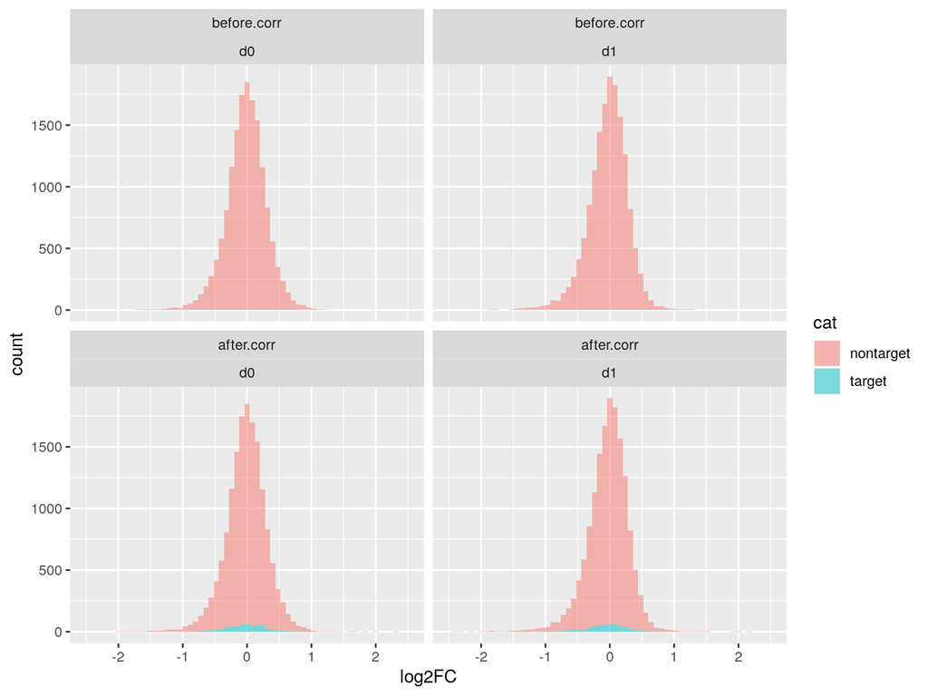

```r
ggplot(m, aes(x=log2FC)) + geom_histogram(aes(fill=cat), alpha=0.5, binwidth=.08) +
  scale_x_continuous(limits = c(-2.5,2.5)) + facet_wrap(~source.1+source)
```

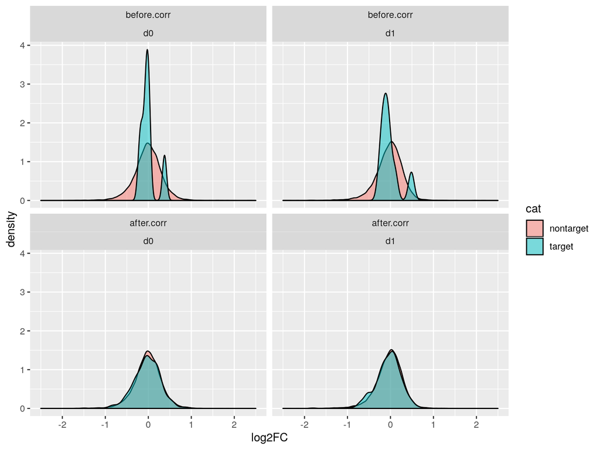

```r
ggplot(m, aes(x=log2FC)) + geom_density(aes(fill=cat), alpha=0.5) +
  scale_x_continuous(limits = c(-2.5,2.5)) + facet_wrap(~source.1+source)
```

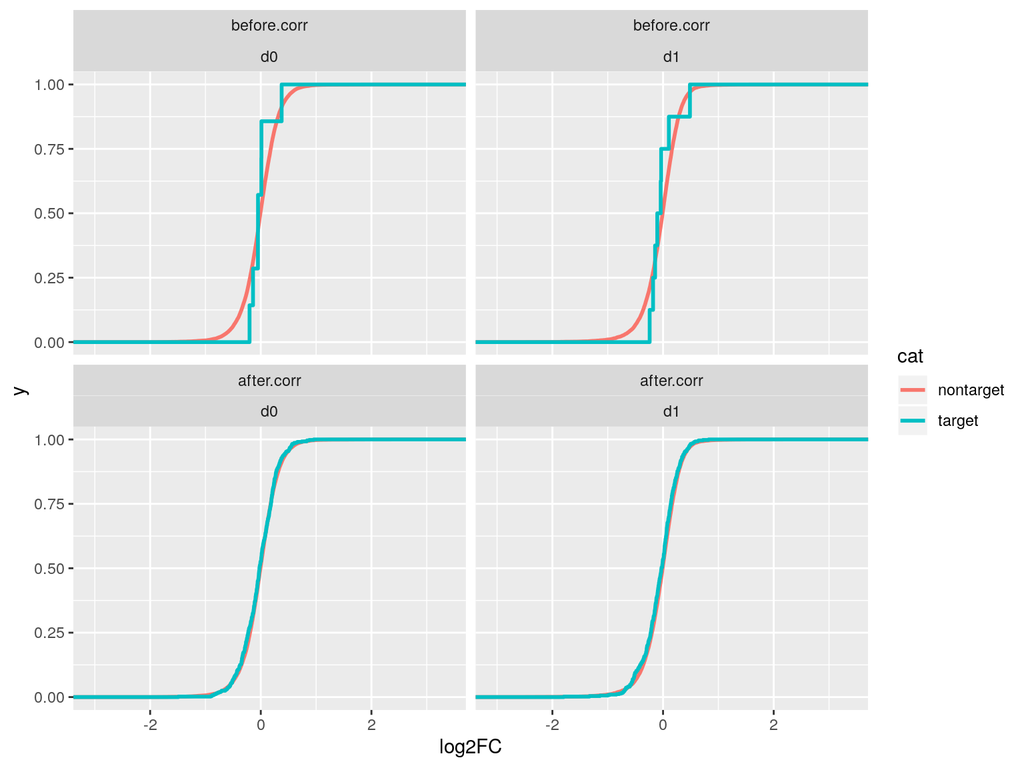

```r
ggplot(m, aes(x=log2FC, colour=cat)) + stat_ecdf(size=1) + facet_wrap(~source.1+source)
```

### TP-FP plots

enrichMiR test scores before and after correction of the Cherone results.

```r
df.agg.old <- DFaggregation(df.old)
df.agg.new <- DFaggregation(df)

df.agg.cherone <- gdata::combine(df.agg.old[df.agg.old$dataset=="cherone",],
                                 df.agg.new[df.agg.new$dataset=="cherone",],
                                 names=c("before.corr", "after.corr"))
```

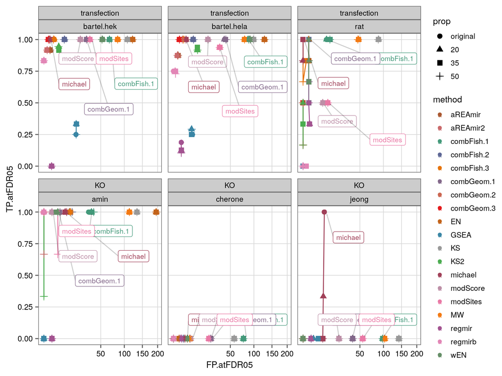

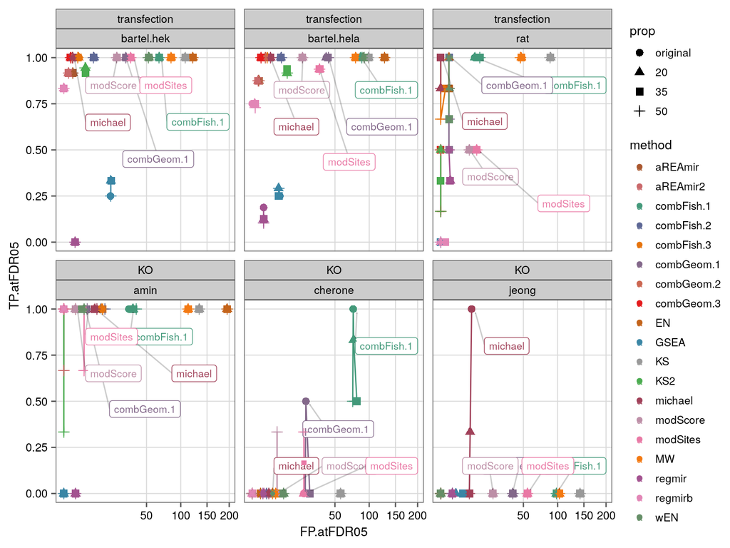

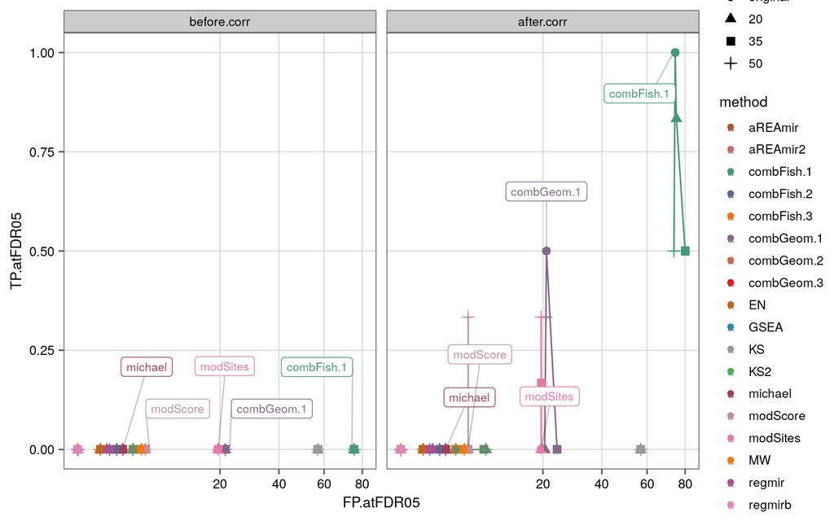

Summary: The number of targets is much higher after correction. The log2FC distributions of targets vs. non-targets seems to be mostly identical. When looking at the density plots it looks like at d1 (after correction) there is a small subset of targets that does show a lower average log2FC. After correction we are able to detect the True seed in some cases with the following enrichMiR tests: *combFish.1*, *combGeom.1*, *modSites*, *modScore*.